# Integrating Crow and OpenAI Models for Reliable Clustering and Label Generation

Crow is a Python package designed to evaluate the stability of clustering algorithms through repeated stochastic clustering. It uses **Element-Centric Similarity (ECS)** and **Element-Centric Consistency (ECC)** to assess the consistency of clustering results across multiple runs.

This notebook demonstrates how to integrate cutting-edge models from OpenAI with Crow to achieve reliable clustering results, extract meaningful insights from the identified clusters, and generate informative labels based on these insights.

```python
from crow import StochasticClusteringRunner, ParameterSearcher, plot_heatmap
from openai import OpenAI
from openai import ChatCompletion
from ast import literal_eval
from sklearn.cluster import KMeans
import matplotlib.pyplot as plt
from umap import UMAP
import sknetwork as skn
import pandas as pd
import numpy as np
import os


# Create embeddings using OpenAI's embedding model
client = OpenAI(api_key="sk-dSaSEPcpRk81gb6xFJTP0AyqKJcKIGAkjknVS9wr5_T3BlbkFJfOXKvb_-3YyFPKC0Q1dFpBO6rY2kqL3hxlYbRvF0UA")
```

```python
df = pd.read_csv('data/fine_food_reviews_1k.csv')
df = df.drop(['Unnamed: 0', 'Time'], axis=1)

# Concatenate all features to a single combined feature.
df['Combined'] = df.apply(lambda row: ", ".join([f"{col}: {row[col]}" for col in df.columns]), axis=1)
```

```python
def get_embedding(text):
    response = client.embeddings.create(
        model="text-embedding-3-small",
        input=text
    )
    return response.data[0].embedding

df['Embedding'] = None
total_rows = len(df)
print("Generating embeddings for each row...")

# Generate embeddings with a progress counter
for index, row in df.iterrows():
    try:
        df.at[index, 'Embedding'] = get_embedding(row['Combined'])
        print(f"Processed row {index + 1} of {total_rows} ({(index + 1) / total_rows:.2%} complete)", end='\r')
    except Exception as e:
        print(f"\nError at row {index + 1}: {e}")

print("\nEmbedding generation complete.")
```

[output not shown]

```python
# df.to_csv("/Users/macbookpro/Desktop/Crow/data/fine_food_reviews_with_embeddings.df")
df = pd.read_csv('data/fine_food_reviews_with_embeddings.df', index_col=0)
```

```python
df['Unique_id'] = [str(i) for i in range(1, len(df) + 1)]
df['Embedding'] = df['Embedding'].apply(literal_eval)
```

```python
# Create a matrix with the high-dimensional embeddings from OpenAI's model.
embedding_matrix = np.vstack(np.array(df['Embedding'].values))
embedding_df = pd.DataFrame(embedding_matrix, columns=[f"Dim_{i+1}" for i in range(embedding_matrix.shape[1])])
```

```python
def plot_umap(embedding_df, color_by=None, color_label=None):
    plt.figure(figsize=(8, 6))

    if color_by is not None:
        groups = embedding_df.groupby(color_by)
        # Choose a categorical colormap with enough distinct colors
        cmap = plt.get_cmap('tab20', len(groups))  # 'tab20' offers up to 20 distinct colors

        for i, (name, group) in enumerate(groups):
            plt.scatter(
                group['UMAP_1'],
                group['UMAP_2'],
                s=5,
                alpha=0.7,
                color=cmap(i),
                label=name
            )
        plt.legend(title=color_label if color_label else color_by, bbox_to_anchor=(1.05, 1), loc='upper left')
    else:
        plt.scatter(
            embedding_df['UMAP_1'],
            embedding_df['UMAP_2'],
            s=5,
            alpha=0.7
        )

    plt.title("UMAP Projection of Embeddings")
    plt.xlabel("UMAP 1")
    plt.ylabel("UMAP 2")
    plt.tight_layout()
    plt.show()
```

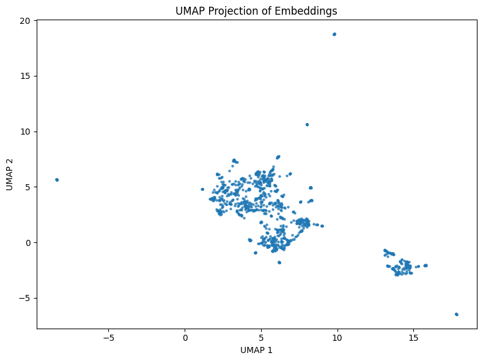

```python
reducer = UMAP(random_state=42)
umap_embs = reducer.fit_transform(embedding_matrix)
umap_embs_df =  pd.DataFrame(umap_embs, columns=["UMAP_1", "UMAP_2"])
umap_embs_df['Unique_id'] = df['Unique_id']
embedding_df['Unique_id'] = df['Unique_id']


plot_umap(umap_embs_df)
```

Let's check the content of the outlier points.

```python
outliers = {}

outliers['left'] = umap_embs_df[umap_embs_df["UMAP_1"] < -2]['Unique_id']
outliers['right'] = umap_embs_df[umap_embs_df["UMAP_1"] > 16]['Unique_id']
outliers['top'] = umap_embs_df[umap_embs_df["UMAP_2"] > 10]['Unique_id']

for key, ids in outliers.items():
    print(key)
    for child_id in ids:
        print(df[df['Unique_id'] == child_id]['Text'].iloc[0])
```

```
left
Rodeo Drive is my absolute favorite and I'm ready to order more!  That's if I can find it.<br />I don't know why they are discontinuing it.<br />It arrived very fast.
Rodeo Drive is my absolute favorite and I'm ready to order more!  That's if I can find it.<br />I don't know why they are discontinuing it.<br />It arrived very fast.
Rodeo Drive is my absolute favorite and I'm ready to order more!  That's if I can find it.<br />I don't know why they are discontinuing it.<br />It arrived very fast.
Rodeo Drive is my absolute favorite and I'm ready to order more!  That's if I can find it.<br />I don't know why they are discontinuing it.<br />It arrived very fast.
Rodeo Drive is my absolute favorite and I'm ready to order more!  That's if I can find it.<br />I don't know why they are discontinuing it.<br />It arrived very fast.
Rodeo Drive is my absolute favorite and I'm ready to order more!  That's if I can find it.<br />I don't know why they are discontinuing it.<br />It arrived very fast.
Rodeo Drive is my absolute favorite and I'm ready to order more!  That's if I can find it.<br />I don't know why they are discontinuing it.<br />It arrived very fast.
Rodeo Drive is my absolute favorite and I'm ready to order more!  That's if I can find it.<br />I don't know why they are discontinuing it.<br />It arrived very fast.
Rodeo Drive is my absolute favorite and I'm ready to order more!  That's if I can find it.<br />I don't know why they are discontinuing it.<br />It arrived very fast.
right
Love this faucet.  My husband had installed the same one in our old house so when our current faucet was leaking I told him not to fix it and we would buy the same one.  It was easy enough for him to install but he did need my assistance a few times to help hold some things in place. Looks great and…
Love this faucet.  My husband had installed the same one in our old house so when our current faucet was leaking I told him not to fix it and we would buy the same one.  It was easy enough for him to install but he did need my assistance a few times to help hold some things in place. Looks great and…
Love this faucet.  My husband had installed the same one in our old house so when our current faucet was leaking I told him not to fix it and we would buy the same one.  It was easy enough for him to install but he did need my assistance a few times to help hold some things in place. Looks great and…
Love this faucet.  My husband had installed the same one in our old house so when our current faucet was leaking I told him not to fix it and we would buy the same one.  It was easy enough for him to install but he did need my assistance a few times to help hold some things in place. Looks great and…
Love this faucet.  My husband had installed the same one in our old house so when our current faucet was leaking I told him not to fix it and we would buy the same one.  It was easy enough for him to install but he did need my assistance a few times to help hold some things in place. Looks great and…
Love this faucet.  My husband had installed the same one in our old house so when our current faucet was leaking I told him not to fix it and we would buy the same one.  It was easy enough for him to install but he did need my assistance a few times to help hold some things in place. Looks great and…
Love this faucet.  My husband had installed the same one in our old house so when our current faucet was leaking I told him not to fix it and we would buy the same one.  It was easy enough for him to install but he did need my assistance a few times to help hold some things in place. Looks great and…
Love this faucet.  My husband had installed the same one in our old house so when our current faucet was leaking I told him not to fix it and we would buy the same one.  It was easy enough for him to install but he did need my assistance a few times to help hold some things in place. Looks great and…
Love this faucet.  My husband had installed the same one in our old house so when our current faucet was leaking I told him not to fix it and we would buy the same one.  It was easy enough for him to install but he did need my assistance a few times to help hold some things in place. Looks great and…
top
First, these should be called Mac - Coconut bars, as Coconut is the #2 ingredient and Mango is #3.  Second, lots of people don't like coconut.  I happen to be allergic to it.  Word to Amazon that if you want happy customers to make things like this more prominent.  Thanks.
First, these should be called Mac - Coconut bars, as Coconut is the #2 ingredient and Mango is #3.  Second, lots of people don't like coconut.  I happen to be allergic to it.  Word to Amazon that if you want happy customers to make things like this more prominent.  Thanks.
```

[output cut: 12 more lines]

The outliers are just repetitive descriptions. Let's remove them from the dataframe.

```python
combined_outliers_ids = [item for value in outliers.values() for item in value]

# Exclude outliers from the two dataframes
df = df[~df['Unique_id'].isin(combined_outliers_ids)]
umap_embs_df = umap_embs_df[~umap_embs_df['Unique_id'].isin(combined_outliers_ids)]
embedding_df = embedding_df[~embedding_df['Unique_id'].isin(combined_outliers_ids)]
```

Let's check the UMAP embeddings after removing the outliers.

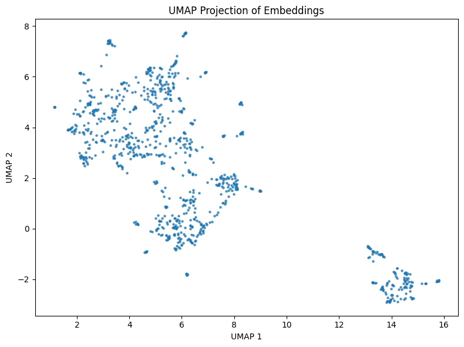

```python
plot_umap(umap_embs_df)
```

# optimize clusters using Crow

```python
# Drop the Unique_id column from the embedding_df after removing the outliers
embedding_df = embedding_df.drop('Unique_id', axis=1)
```

Now let's cluster the high-dimensional embeddings using k-means from `scikit-learn` and `crow`. We will run the algorithm 30 times, check it's clustering stability over repeated iterations, and get the majority voting label for each sample.

Let's start with the default hyperparameters.

```python
# Trying to cluster with default parameters of KMeans
repeated_kmeans_func = StochasticClusteringRunner(
    KMeans, "random_state", n_runs=30, verbose=False
)
results_repeated_kmeans = repeated_kmeans_func.run(embedding_df)
```

```python
pd.Series(results_repeated_kmeans['ecc']).describe()
```

```
count    968.000000
mean       0.562198
std        0.170154
min        0.233766
25%        0.425968
50%        0.526472
75%        0.694091
max        0.840365
dtype: float64
```

```python
# Find the optimal parameters based on ECC - similar to fine tuning in supervised learning.
param_grid = {"n_clusters": np.arange(3, 12, 1), "init": ["k-means++", "random"]}

parameter_searcher = ParameterSearcher(
    clustering_algo=KMeans,
    parameter_name_seed="random_state",
    param_grid=param_grid,
    n_runs=30,
    verbose=False,
)
searcher_summarised_df, searcher_clustering_results = parameter_searcher.run(embedding_df)
```

```
Automatically selected keys for visualization: n_clusters, init
Creating DataFrame from parameter search results...
No duplicates found. Pivoting directly...
```

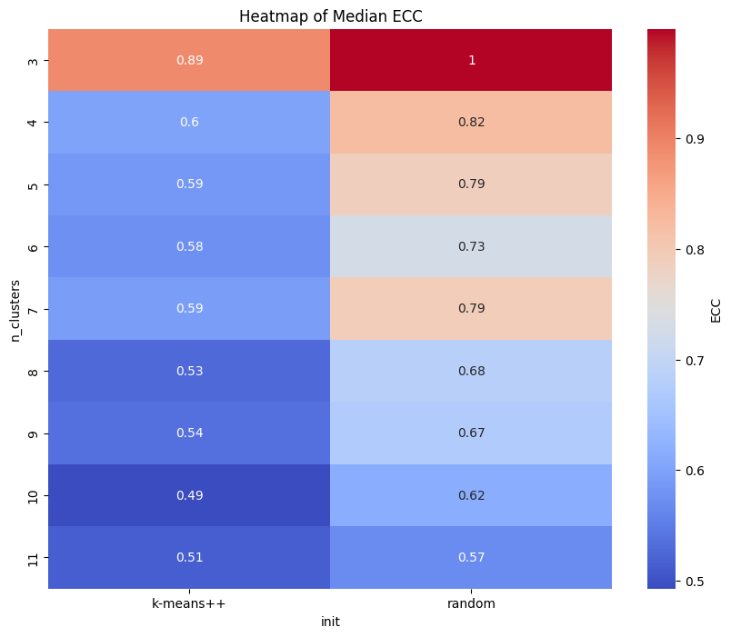

```python
plot_heatmap(searcher_summarised_df)
```

The random initialisation k-means seems to producing results that are more robust to technical variations - i.e., the results change less over repeated iterations with different seeds.

We get the most stable clustering results when `n_clusters` is 3, 4, 5, and 7.

Let's try to use OpenAI's `GPT-4o-mini` to understand better the content of each cluster and try to automatically get a label for each cluster.

```python
umap_embs_df.loc[:, 'n_clusters_3_init_random'] = searcher_clustering_results['n_clusters_3_init_random']['majority_voting_labels']
df.loc[:, 'n_clusters_3_init_random'] = searcher_clustering_results['n_clusters_3_init_random']['majority_voting_labels']
```

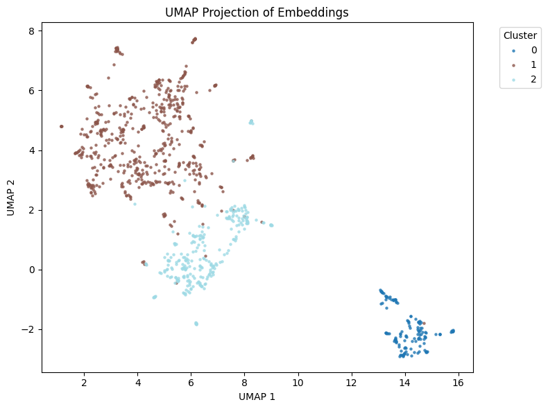

```python
plot_umap(umap_embs_df, color_by='n_clusters_3_init_random', color_label='Cluster')
```

```python
# Define the OpenAI completions model and API key
COMPLETIONS_MODEL = "gpt-4o-mini-2024-07-18"

# Function to generate a prompt for analyzing clusters
def generate_prompt(cluster_id, sample_reviews):
    prompt = f"""
    Cluster {cluster_id} Reviews:
    {sample_reviews}

    --Instructions--
    # Theme: Identify the main product or topic.
    # Sentiment: State whether the reviews are predominantly positive, negative, or mixed.
    # Variability: List succinctly all the different items in this cluster.
    # Patterns: List any repeated words, phrases, or issues.
    # Label: Suggest a short label for this cluster.
    """
    return prompt

# Function to analyze a cluster using OpenAI's completions model
def analyze_cluster(cluster_id, df_cluster, model=COMPLETIONS_MODEL):
    sample_reviews = "\n".join(df_cluster['Summary'].tolist())
    prompt = generate_prompt(cluster_id, sample_reviews)

    response = client.chat.completions.create(
        messages=[
            {
                "role": "user",
                "content": prompt,
            }
        ],
        model=model,
        max_tokens=500,
        temperature=0.7
    )
    return response.choices[0].message.content

def print_description_of_clusters(df, labels):
    cluster_analysis_dict = {}

    # Iterate through clusters and analyze them
    for cluster in sorted(df[labels].unique()):
        df_cluster = df[df[labels] == cluster]
        print(f"Cluster {cluster}:")
        cluster_analysis_dict[f'cluster_{cluster}'] = analyze_cluster(cluster, df_cluster)
        print(cluster_analysis_dict[f'cluster_{cluster}'])
        print("-" * 100)
        print()
```

```python
# Let's check the description of the 3 clusters.
print_description_of_clusters(df, "n_clusters_3_init_random")
```

```
Cluster 0:
**Theme:** Dog and Cat Food/Treats

**Sentiment:** Predominantly positive, with some negative reviews.

**Variability:**
- Dog treats (e.g., WAGGIN TRAIN CHIK'N BISCUITS, Fruitables Crunchy Dog Treats)
- Dog food (e.g., Premium Dog Food, Blue Buffalo Wilderness)
- Cat food/treats (e.g., Good for all cats)
- Pill pockets
- Chew toys (e.g., Nylabone DuraChew)
- Specific flavors (e.g., peanut butter)
- Health-related products (e.g., for hips)

**Patterns:**
- Frequent mentions of dogs loving the products ("my dogs love them," "Dogs love it.")
- Some negative experiences ("Food caused illness," "TOXIC INGREDIENTS!")
- Repeated mentions of "Messy and apparently undelicious"
- Some customers expressed confusion or mixed feelings ("Not sure how to feel")
- Multiple mentions of finding low prices or specific sizes ("finding low price and 12 oz cans is tough")
- Reference to specific breeds (e.g., Yorkie, Pit Bull, Chihuahuas)

**Label:** Pet Food and Treats Feedback
----------------------------------------------------------------------------------------------------

Cluster 1:
### Cluster Analysis

**Theme:** This cluster primarily revolves around snacks, treats, and various food items, with a focus on gluten-free options, healthy snacks, and specific brands.

**Sentiment:** The reviews are predominantly positive, with many expressions of enjoyment and satisfaction regarding the taste and quality of the products, though there are some negative reviews regarding packaging and misleading descriptions.

**Variability:**
- Gluten-free bars and snacks
- Cookies (e.g., oatmeal cookies, chocolate chip cookies)
- Popcorn
- Seasonings and sauces (e.g., spicy pepper sauce, marinades)
- Maple syrup
- Instant noodles
- Cereal and breakfast items
```

[output cut: 21 more lines]

```
- Tea (Black tea, English breakfast, green tea, rooibos, peppermint, etc.)
- Matcha (Incredible matcha, Caramel Matcha-yum!)
- Coffee (various brands including Emeril's, Wolfgang Puck, San Francisco Bay Coffee, Tully's, etc.)
- Decaf options (Newman's Own Organics Decaf Cups)
- Hot Apple Cider
- French Vanilla (Cappuccino, Wolfgang Puck)
- Other beverages (Half and half Iced Tea, smoothies, etc.)

**Patterns:**
- Frequent mentions of "great taste," "best coffee," "love this stuff," "not as strong," "disappointed," "not what I expected," and "buyer beware."
- Repeated references to specific brands such as Emeril's, Wolfgang Puck, and Newman's Own.
- Comments on delivery issues and consistency of flavor.

**Label:** Coffee & Tea Enthusiasts Reviews
----------------------------------------------------------------------------------------------------
```

Based on the analysis by the model we can see that `cluster`=0 is mostly about pet food and treats, `cluster`=1 is about delicious treats and healthy snacks (human-ones 😅), and `cluster`=2 is about coffee and tea enthusiast.

Let's run the same process for when the `n_clusters`=7 to see if we will get a more-detailed/fine-grained understanding of the clusters.

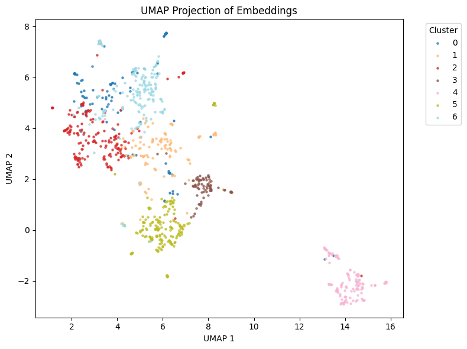

```python
umap_embs_df.loc[:, 'n_clusters_7_init_random'] = searcher_clustering_results['n_clusters_7_init_random']['majority_voting_labels']
df.loc[:, 'n_clusters_7_init_random'] = searcher_clustering_results['n_clusters_7_init_random']['majority_voting_labels']

plot_umap(umap_embs_df, color_by='n_clusters_7_init_random', color_label='Cluster')
```

```python
# Let's check the description of the 7 clusters.
print_description_of_clusters(df, "n_clusters_7_init_random")
```

```
Cluster 0:
- **Theme:** Food products (specifically snacks and cereals)
- **Sentiment:** Predominantly negative
- **Variability:**
  - Broken or damaged items (e.g., arrived in pieces, damaged can)
  - Deceptive product descriptions (e.g., misleading label, deceptive description)
  - Poor taste or quality (e.g., bland, inedible, tasted stale)
  - High price complaints (e.g., ridiculous price, small fortune spent)
  - Health concerns (e.g., contains aspartame, warning cancer)
  - Flavor complaints (e.g., good flavor but a wet mess, not what I expected)
  - Disappointment with specific products (e.g., these are not the oysters you want, not for sprouting)

- **Patterns:**
  - Frequent mentions of "deceptive description" and "disappointed"
  - Repeated feedback about flavor issues, often paired with wet or messy consistency
  - Complaints about price being too high for the quality received
  - Many reviews express dissatisfaction with product condition upon arrival (broken, stale, damaged)

- **Label:** "Disappointment in Food Products"
----------------------------------------------------------------------------------------------------

Cluster 1:
**Theme:** Beverage Products and Sweeteners

**Sentiment:** Predominantly positive

**Variability:**
- Coconut water
- Maple syrup (Hidden Springs and Andersons grade B)
- Energy drinks (5 Hour Energy, ZipFizz)
- Mousse
- Hard candy (Stevia Sweetened)
- Wine (Tobin James)
- Cider (Hot Apple Cider)
- Drink mixes (Metromint, Hint Fizz)
- Xylitol
- Electrolyte replacement drinks (Gatorade)
- Vanilla extract
- Figs

```

[output cut: 143 more lines]

```
- Cornbread mix
- Gluten-free products
- Seasonings and spices
- Cooking sauces

### Patterns:
- Frequent mentions of taste and quality (e.g., "Delicious," "Great taste," "Tasty")
- Positive phrases like "Great product," "Love this stuff," and "Outstanding product"
- Several references to convenience and suitability for specific diets (e.g., Paleo)
- Repeated positive mentions of popcorn
- Occasional comments on price/value (e.g., "not worth the money," "price must be a misprint")

### Label:
"Delicious Finds: Quality Food Products and Seasonings"
----------------------------------------------------------------------------------------------------
```

The shift to more clusters has indeed provided a better understanding of customer feedback. For instance, what was once a mixed group of beverage-related reviews is now separated into distinct clusters for beverages and sweeteners, teas, and coffee pods. This separation allows us to pinpoint not only the general sentiment around beverages but also the unique nuances within each subgroup.